# practicum

Jackson Ayieko

May 16, 2019

The initial step of this assignment was to load the data into R as below

```r
behavior_factors <- read.csv("Behavioral_Risk.csv", header = T)
View(behavior_factors)
```

After loading the data set set, I realized there are many behavioral factors that are covered and the data file is really large, I decided to select 5 behavioral factors to focus on. These include COPD,cardiovascular diseases, kidney, depression, and binge drinking. Here are the steps used to select the target behavior factors.

```r
library(dplyr)
library(stringr)
```

```r
library(tidyr)
library(ggplot2)

tb1 <- filter(behavior_factors, Topic =="COPD")
tb2 <- filter(behavior_factors, Topic =="Kidney")
tb3 <- filter(behavior_factors, Topic =="Depression")
tb4 <- filter(behavior_factors, Topic =="Binge Drinking")
tb5 <- filter(behavior_factors, Topic =="Cardiovascular Disease")
target_behaviors <- rbind(tb1,tb2,tb3, tb4, tb5)
View(target_behaviors)
```

Now that I have the target data set, am focusing on getting to understand the data set well. The first step was to clean up the data set and remove unwanted columns that may not be relevant for analysis. Here are the steps used:

selecting the target columns from the data set

```r
#target column
targ_b <- select(target_behaviors, Year:Response, Sample_Size, Geolocation)
targ_b$Locationdesc <- as.character(targ_b$Locationdesc)
targ_b$Geolocation <- gsub(",",":", targ_b$Geolocation)
targ_b <- targ_b %>% separate(Geolocation, c('Lat', 'Lon'), sep = ":")
View(targ_b)
str(targ_b)
```

```
## 'data.frame':    5420 obs. of  10 variables:
##  $ Year        : int  2011 2011 2011 2011 2011 2011 2011 2011 2011 2011 ...
##  $ Locationabbr: Factor w/ 54 levels "AK","AL","AR",..: 2 2 1 1 4 4 3 3 5 5 ...
##  $ Locationdesc: chr  "Alabama" "Alabama" "Alaska" "Alaska" ...
##  $ Class       : Factor w/ 19 levels "Alcohol Consumption",..: 3 3 3 3 3 3 3 3 3 3 ...
##  $ Topic       : Factor w/ 55 levels "Aerobic Activity",..: 13 13 13 13 13 13 13 13 13 13 ...
##  $ Question    : Factor w/ 79 levels "About how long has it been since you last visited a doctor for a routine checkup?",..: 49 49 49 49 49 49 49 49 49 49 ...
##  $ Response    : Factor w/ 78 levels "5 or more years ago",..: 73 43 73 43 73 43 73 43 73 43 ...
##  $ Sample_Size : int  919 6735 216 3313 578 5869 524 4178 1097 15794 ...
##  $ Lat         : chr  "(32.84057112200048" "(32.84057112200048" "(64.84507995700051" "(64.84507995700051" ...
##  $ Lon         : chr  " -86.63186076199969)" " -86.63186076199969)" " -147.72205903599973)" " -147.72205903599973)" ...
```

```r
# getting copd data 2011
targ_copd <- filter(targ_b, Year == "2011", Response == "Yes", Topic == "COPD")
View(targ_copd)
```

For my analysis am focusing on top five and bottom five for each of the five topics (copd, depression, binge drinking, depression and cardiovascular diseases). Am going to compare each and see which state have the highest cases or the lowest cases of each. Am planning to use bar plots as my visualization tool for easy comparison. Here are the steps used:

plotting top 5 based on sample size for 2011

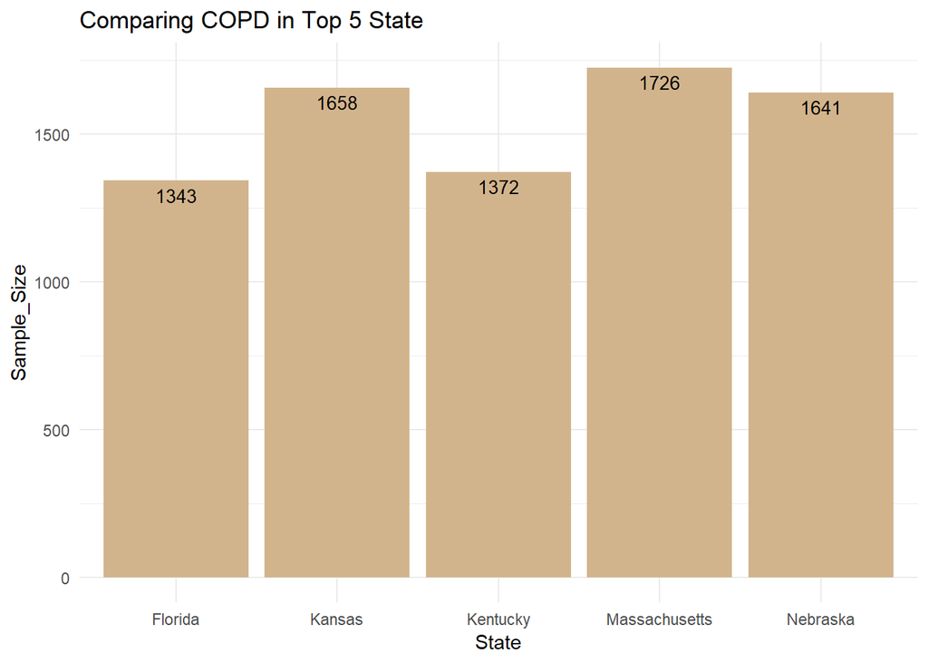

```r
top_n(targ_copd, n=5, Sample_Size) %>%
  ggplot(., aes(x=Locationdesc, y=Sample_Size))+ labs(title = "Comparing COPD in Top 5 State", x = "State") +
  geom_bar(stat = 'identity', fill = "tan")+ geom_text(aes(label=Sample_Size), vjust=1.5, color="black", size = 3.5)+ theme_minimal()
```

In 2011 the state of Massachussetts had the highest number of COPD cases followed by Kansas.

bottom 5 COPD states

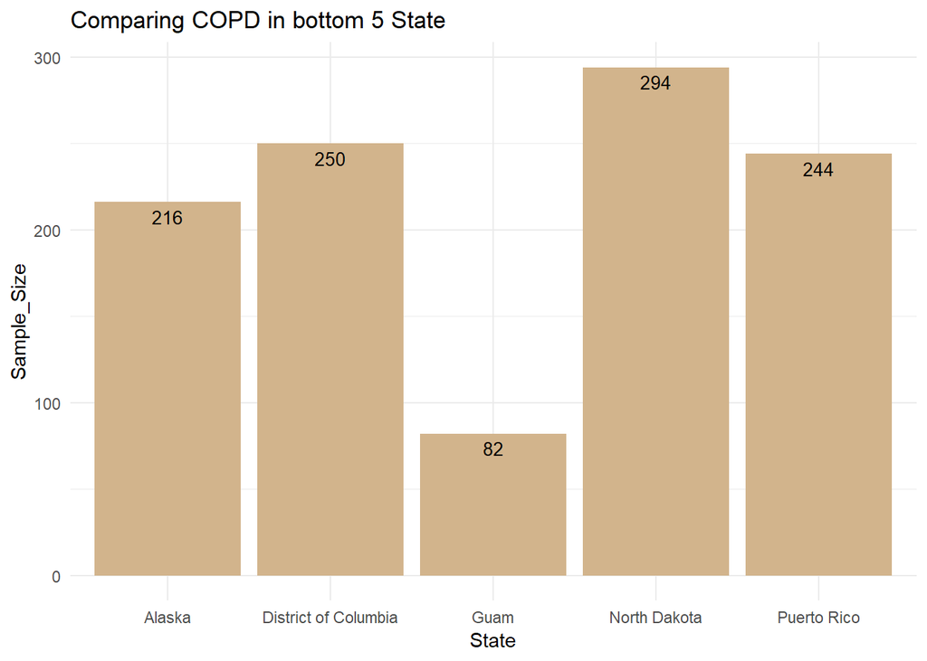

```r
top_n(targ_copd, n=-5, Sample_Size) %>%
  ggplot(., aes(x=Locationdesc, y=Sample_Size))+ labs(title = "Comparing COPD in bottom 5 State", x = "State") +
  geom_bar(stat = 'identity', fill = "tan")+ geom_text(aes(label=Sample_Size), vjust=1.5, color="black", size = 3.5)+ theme_minimal()
```

The state of Guam had the lowest cases of COPd in 2011. COPD data top 5 for 2012

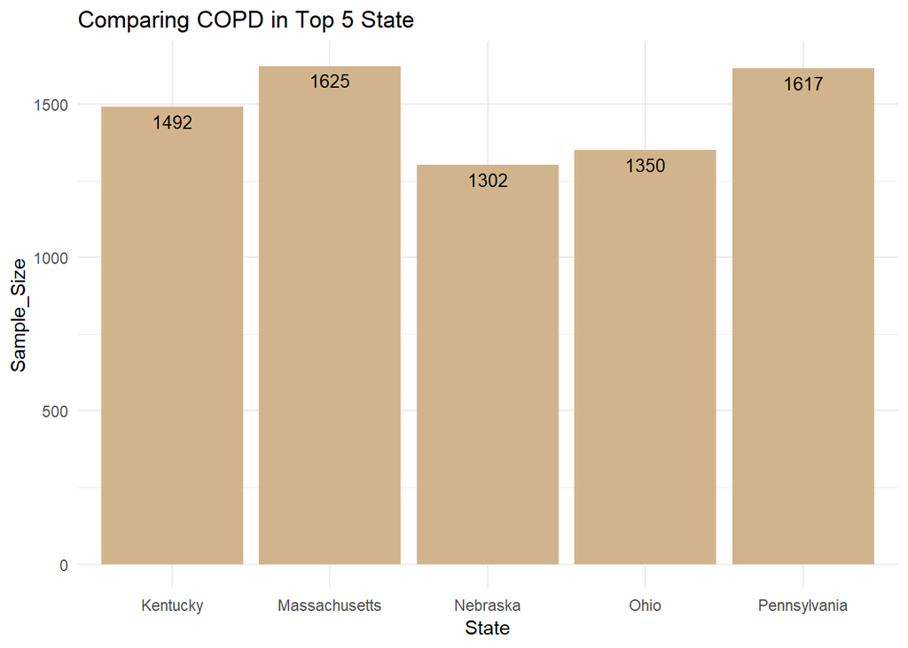

```r
targ_copd2 <- filter(targ_b, Year == "2012", Response == "Yes", Topic == "COPD")
View(targ_copd2)
# plotting top 5 based on sample size for 2012

top_n(targ_copd2, n=5, Sample_Size) %>%
  ggplot(., aes(x=Locationdesc, y=Sample_Size))+ labs(title = "Comparing COPD in Top 5 State", x = "State") +
  geom_bar(stat = 'identity', fill = "tan")+ geom_text(aes(label=Sample_Size), vjust=1.5, color="black", size = 3.5)+ theme_minimal()
```

In 2012 Masschusetts still recorded the highest number of COPD, followed by Pennslyvania.

COPD data bottom 5 for 2012

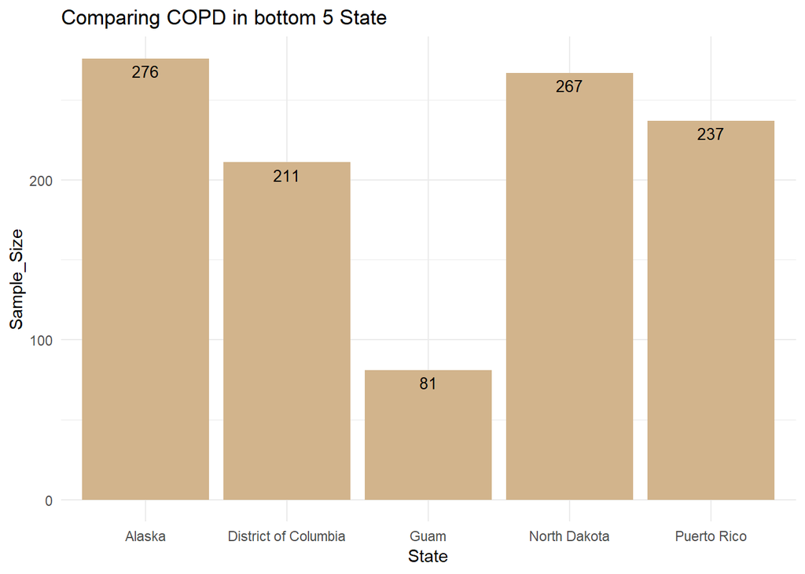

```r
# plotting the bottom 5 COPD for 2012
top_n(targ_copd2, n=-5, Sample_Size) %>%
  ggplot(., aes(x=Locationdesc, y=Sample_Size))+ labs(title = "Comparing COPD in bottom 5 State", x = "State") +
  geom_bar(stat = 'identity', fill = "tan")+ geom_text(aes(label=Sample_Size), vjust=1.5, color="black", size = 3.5)+ theme_minimal()
```

Guam still recorded the lowest cases of COPD at 81. COPD data top 5 for 2013

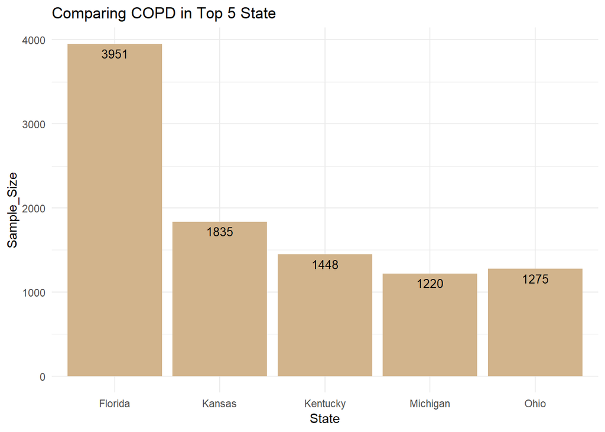

```r
targ_copd3 <- filter(targ_b, Year == "2013", Response == "Yes", Topic == "COPD")
View(targ_copd3)
# plotting top 5 based on sample size for 2013

top_n(targ_copd3, n=5, Sample_Size) %>%
  ggplot(., aes(x=Locationdesc, y=Sample_Size))+ labs(title = "Comparing COPD in Top 5 State", x = "State") +
  geom_bar(stat = 'identity', fill = "tan")+ geom_text(aes(label=Sample_Size), vjust=1.5, color="black", size = 3.5)+ theme_minimal()
```

COPD data bottom 5 for 2013

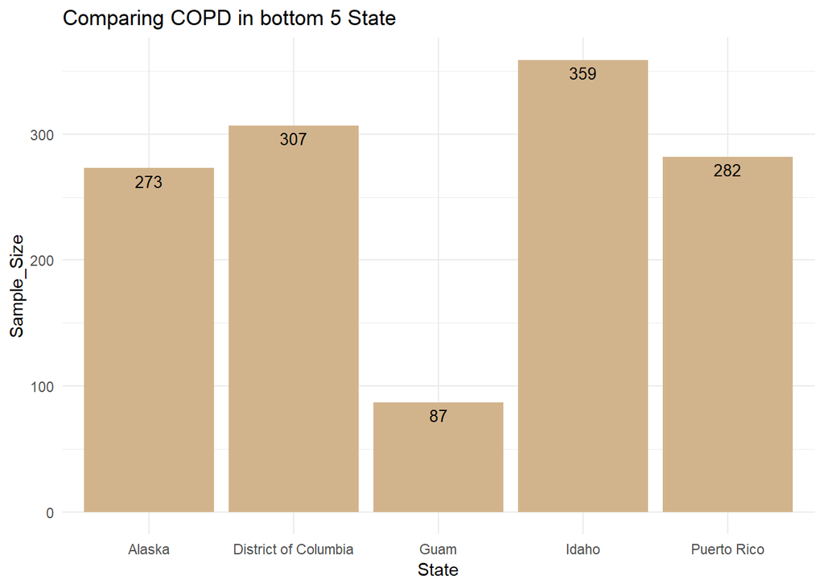

```r
# plotting the bottom 5 COPD for 2013
top_n(targ_copd3, n=-5, Sample_Size) %>%
  ggplot(., aes(x=Locationdesc, y=Sample_Size))+ labs(title = "Comparing COPD in bottom 5 State", x = "State") +
  geom_bar(stat = 'identity', fill = "tan")+ geom_text(aes(label=Sample_Size), vjust=1.5, color="black", size = 3.5)+ theme_minimal()
```

In 2013, Florida had th highest cases of COPD while Guam still had the lowest numbers.

COPD data top 5 for 2014

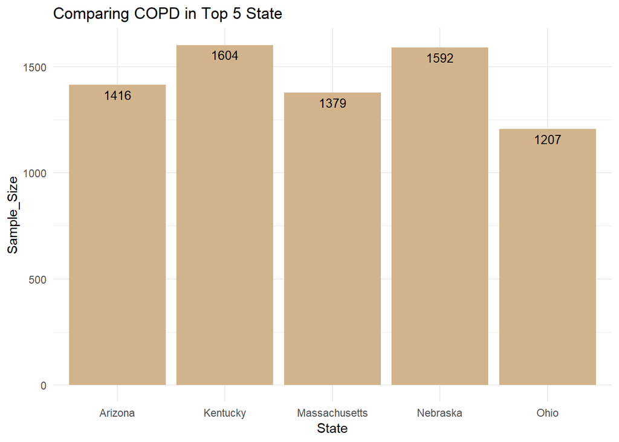

```r
targ_copd4 <- filter(targ_b, Year == "2014", Response == "Yes", Topic == "COPD")
View(targ_copd4)
# plotting top 5 based on sample size for 2013

top_n(targ_copd4, n=5, Sample_Size) %>%
  ggplot(., aes(x=Locationdesc, y=Sample_Size))+ labs(title = "Comparing COPD in Top 5 State", x = "State") +
  geom_bar(stat = 'identity', fill = "tan")+ geom_text(aes(label=Sample_Size), vjust=1.5, color="black", size = 3.5)+ theme_minimal()
```

COPD data bottom 5 for 2014

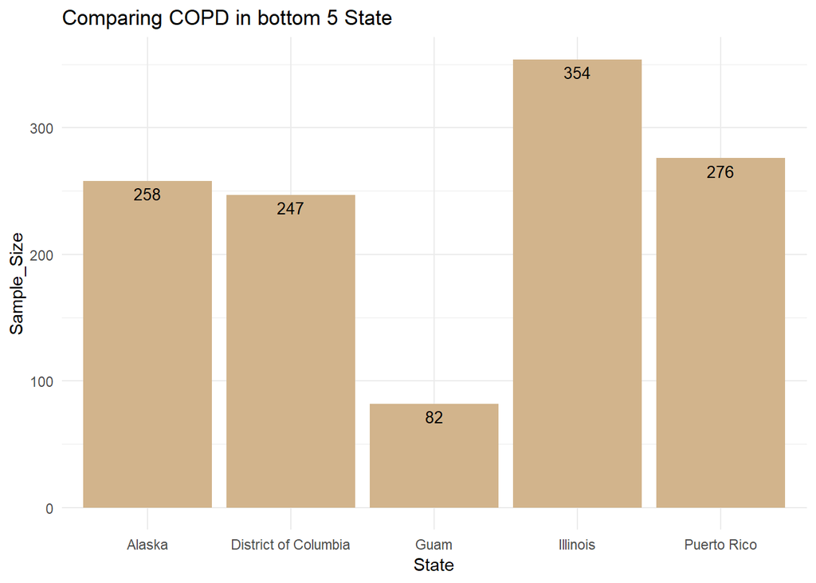

```r
# plotting the bottom 5 COPD for 2014
top_n(targ_copd4, n=-5, Sample_Size) %>%
  ggplot(., aes(x=Locationdesc, y=Sample_Size))+ labs(title = "Comparing COPD in bottom 5 State", x = "State") +
  geom_bar(stat = 'identity', fill = "tan")+ geom_text(aes(label=Sample_Size), vjust=1.5, color="black", size = 3.5)+ theme_minimal()
```

COPD data top 5 for 2015

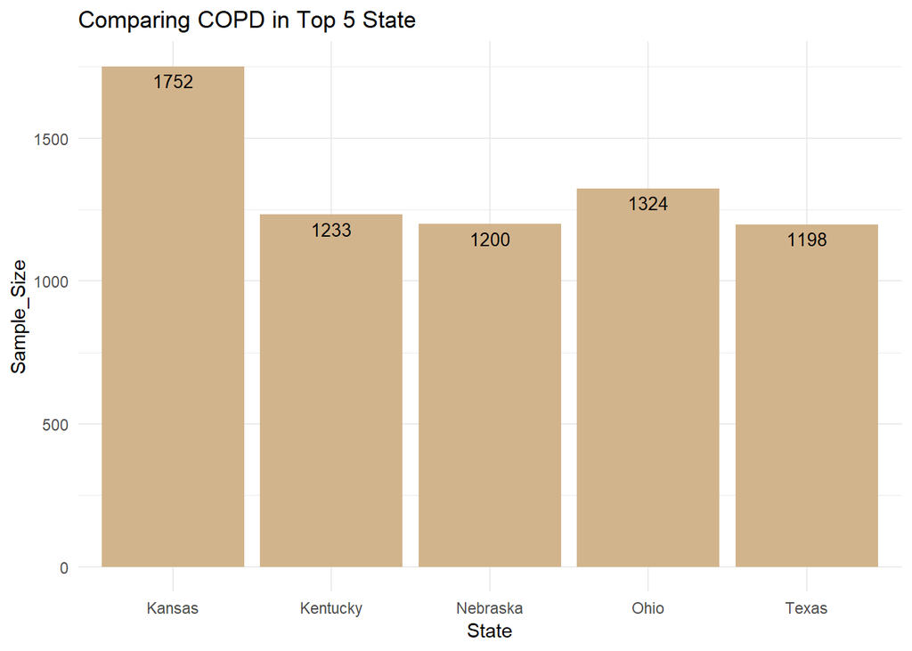

```r
targ_copd5 <- filter(targ_b, Year == "2015", Response == "Yes", Topic == "COPD")
View(targ_copd5)
# plotting top 5 based on sample size for 2013

top_n(targ_copd5, n=5, Sample_Size) %>%
  ggplot(., aes(x=Locationdesc, y=Sample_Size))+ labs(title = "Comparing COPD in Top 5 State", x = "State") +
  geom_bar(stat = 'identity', fill = "tan")+ geom_text(aes(label=Sample_Size), vjust=1.5, color="black", size = 3.5)+ theme_minimal()
```

In 2014,Kentacky had the highest number of COPD while Guam still recorded the lowest cases of COPD.

COPD data bottom 5 for 2015

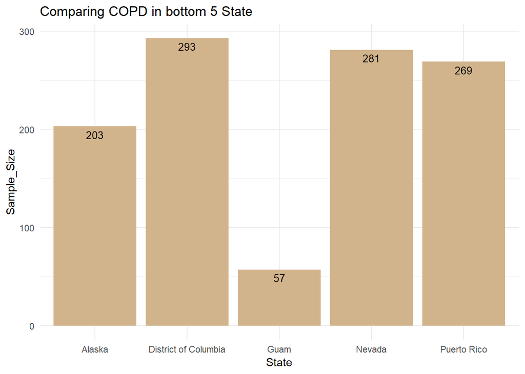

```r
# plotting the bottom 5 COPD for 2015
top_n(targ_copd5, n=-5, Sample_Size) %>%
  ggplot(., aes(x=Locationdesc, y=Sample_Size))+ labs(title = "Comparing COPD in bottom 5 State", x = "State") +
  geom_bar(stat = 'identity', fill = "tan")+ geom_text(aes(label=Sample_Size), vjust=1.5, color="black", size = 3.5)+ theme_minimal()
```

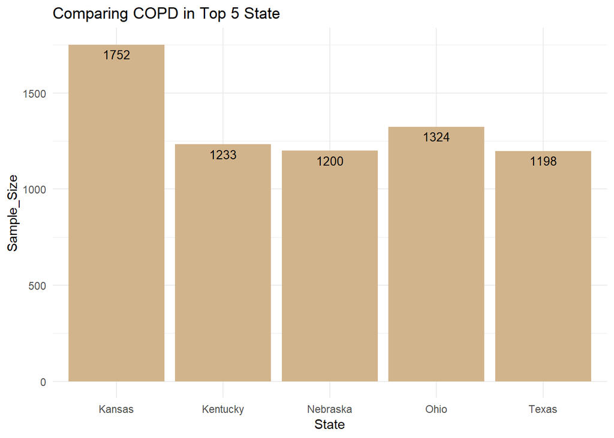

```r
targ_copd6 <- filter(targ_b, Year == "2016", Response == "Yes", Topic == "COPD")
View(targ_copd6)
# plotting top 5 based on sample size for 2016

top_n(targ_copd5, n=5, Sample_Size) %>%
  ggplot(., aes(x=Locationdesc, y=Sample_Size))+ labs(title = "Comparing COPD in Top 5 State", x = "State") +
  geom_bar(stat = 'identity', fill = "tan")+ geom_text(aes(label=Sample_Size), vjust=1.5, color="black", size = 3.5)+ theme_minimal()
```

COPD data bottom 5 for 2016

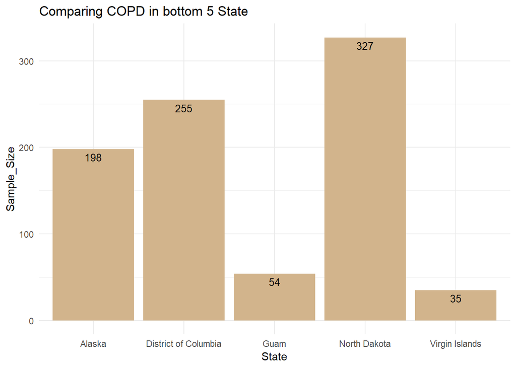

```r
# plotting the bottom 5 COPD for 2016
top_n(targ_copd6, n=-5, Sample_Size) %>%
  ggplot(., aes(x=Locationdesc, y=Sample_Size))+ labs(title = "Comparing COPD in bottom 5 State", x = "State") +
  geom_bar(stat = 'identity', fill = "tan")+ geom_text(aes(label=Sample_Size), vjust=1.5, color="black", size = 3.5)+ theme_minimal()
```

**COPD data top 5 for 2017**

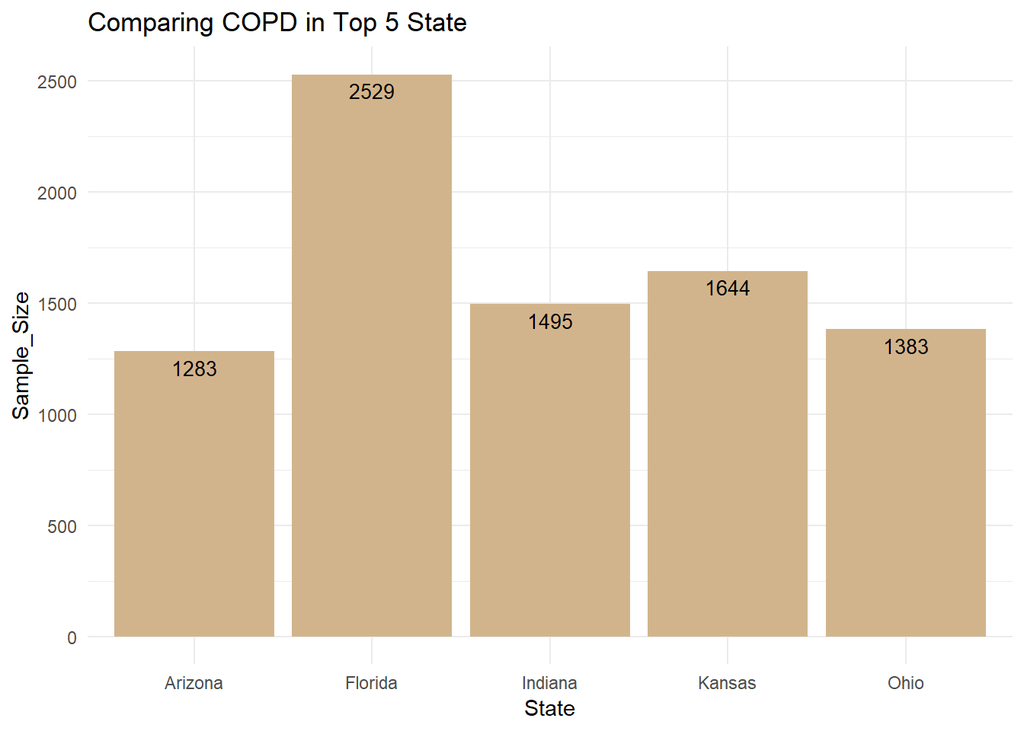

```r
targ_copd7 <- filter(targ_b, Year == "2017", Response == "Yes", Topic == "COPD")
View(targ_copd7)
# plotting top 5 based on sample size for 2017

top_n(targ_copd7, n=5, Sample_Size) %>%
  ggplot(., aes(x=Locationdesc, y=Sample_Size))+ labs(title = "Comparing COPD in Top 5 State", x = "State") +
  geom_bar(stat = 'identity', fill = "tan")+ geom_text(aes(label=Sample_Size), vjust=1.5, color="black", size = 3.5)+ theme_minimal()
```

COPD data bottom 5 for 2017

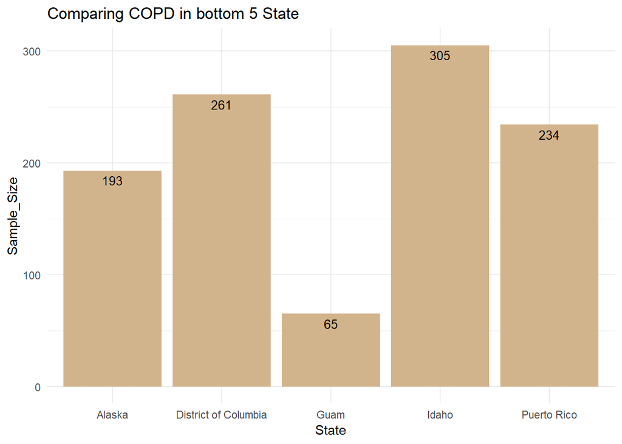

```r
# plotting the bottom 5 COPD for 2017
top_n(targ_copd7, n=-5, Sample_Size) %>%
  ggplot(., aes(x=Locationdesc, y=Sample_Size))+ labs(title = "Comparing COPD in bottom 5 State", x = "State") +
  geom_bar(stat = 'identity', fill = "tan")+ geom_text(aes(label=Sample_Size), vjust=1.5, color="black", size = 3.5)+ theme_minimal()
```

In 2017 Florida had the most cases of COPD while GUAM had the lowest cases.

The next topic I covered is the Kidney diseases in the USA. I first started by selecting the section of the data set of interest.

```r
# getting kidney data 2011
targ_kid <- filter(targ_b, Year == "2011", Response == "Yes", Topic == "Kidney")
View(targ_kid)
```

With the data selected, the next tep was to get the top 5 and bottom 5 states based on the kidney data. Here are the steps used:

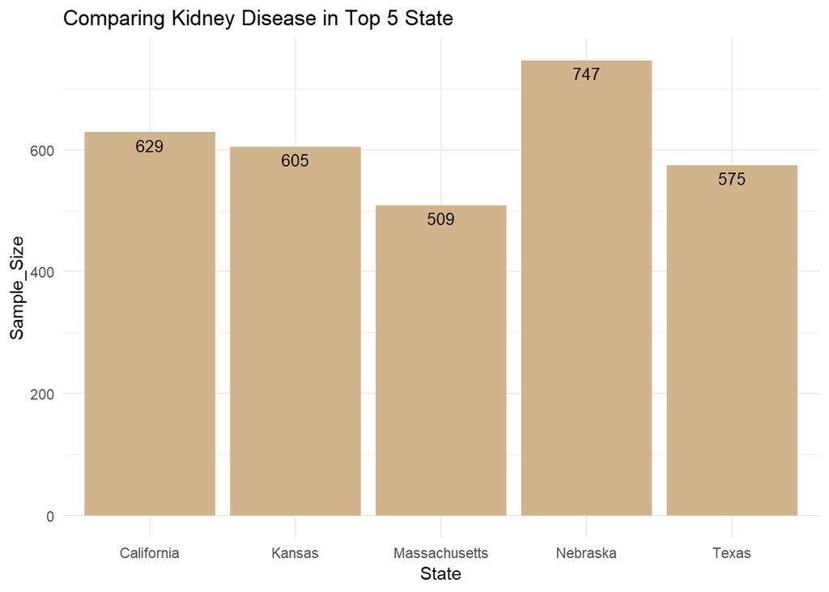

```r
# top 5 states with kidney disease 2011
top_n(targ_kid, n=5, Sample_Size) %>%
  ggplot(., aes(x=Locationdesc, y=Sample_Size))+ labs(title = "Comparing Kidney Disease in Top 5 State", x = "State") +
  geom_bar(stat = 'identity', fill = "tan")+ geom_text(aes(label=Sample_Size), vjust=1.5, color="black", size = 3.5)+ theme_minimal()
```

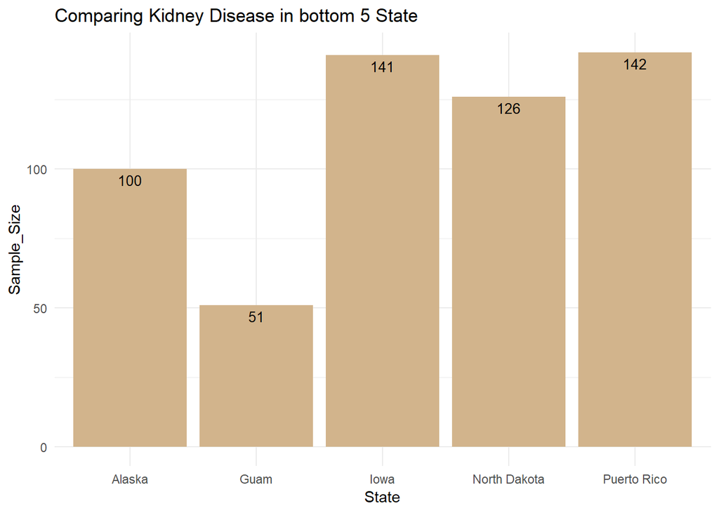

```r
# plotting the bottom 5 states with kidney disease for 2011
top_n(targ_kid, n=-5, Sample_Size) %>%
  ggplot(., aes(x=Locationdesc, y=Sample_Size))+ labs(title = "Comparing Kidney Disease in bottom 5 State", x = "State") +
  geom_bar(stat = 'identity', fill = "tan")+ geom_text(aes(label=Sample_Size), vjust=1.5, color="black", size = 3.5)+ theme_minimal()
```

The second condition I covered was kidney disease. In 2011, Nebraska had the most cases while Guam had the lowest cases of Kidey disease.

2012 kidney disease data

```r
# getting kidney data 2012
targ_kid2 <- filter(targ_b, Year == "2012", Response == "Yes", Topic == "Kidney")
View(targ_kid2)
```

getting the top 5 states with kidney disease 2012

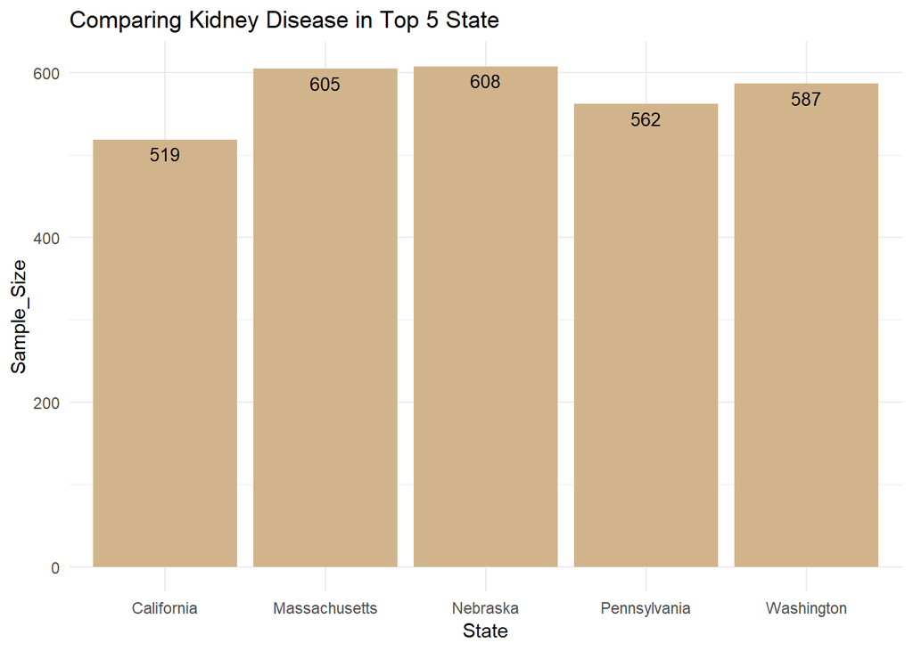

```r
# top 5 states with kidney disease 2012
top_n(targ_kid2, n=5, Sample_Size) %>%
  ggplot(., aes(x=Locationdesc, y=Sample_Size))+ labs(title = "Comparing Kidney Disease in Top 5 State", x = "State") +
  geom_bar(stat = 'identity', fill = "tan")+ geom_text(aes(label=Sample_Size), vjust=1.5, color="black", size = 3.5)+ theme_minimal()
```

getting bottom 5 states kidney disease 2012

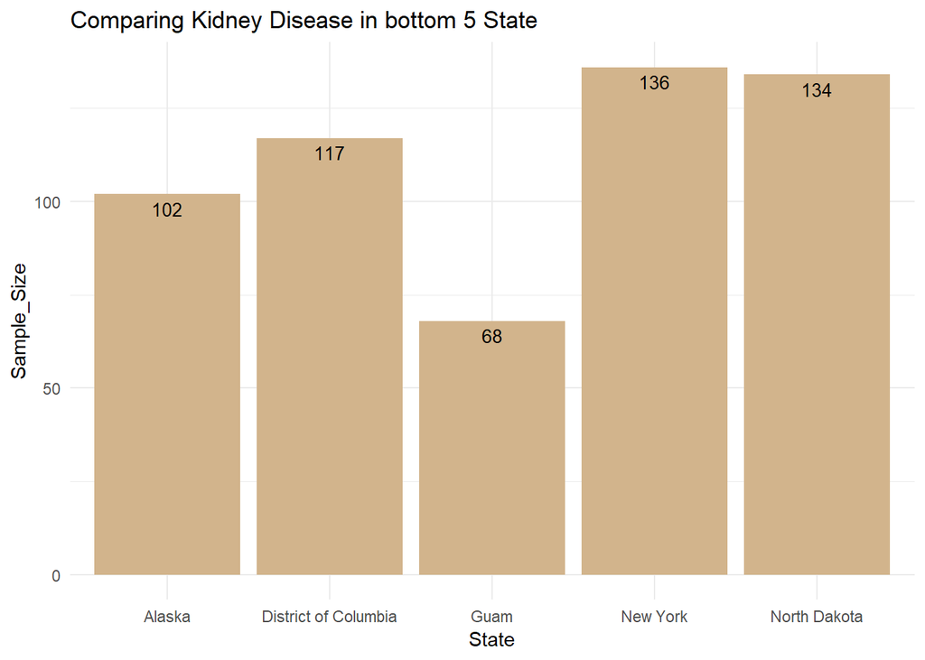

```r
# plotting the bottom 5 states with kidney disease for 2012
top_n(targ_kid2, n=-5, Sample_Size) %>%
  ggplot(., aes(x=Locationdesc, y=Sample_Size))+ labs(title = "Comparing Kidney Disease in bottom 5 State", x = "State") +
  geom_bar(stat = 'identity', fill = "tan")+ geom_text(aes(label=Sample_Size), vjust=1.5, color="black", size = 3.5)+ theme_minimal()
```

In 2012 the cases remained the same with Nebraska still having the highest case while Guam had the least number of Kidney disease cases.

**2013 kidney disease data**

```r
# getting kidney data 2013
targ_kid3 <- filter(targ_b, Year == "2013", Response == "Yes", Topic == "Kidney")
View(targ_kid3)
```

**getting the top 5 states with kidney disease 2013**

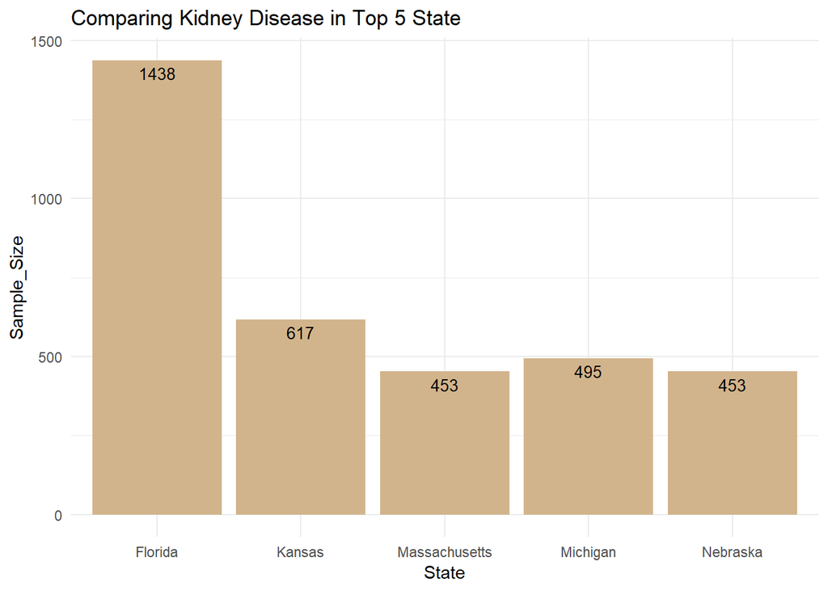

```r
# top 5 states with kidney disease 2013
top_n(targ_kid3, n=5, Sample_Size) %>%
  ggplot(., aes(x=Locationdesc, y=Sample_Size))+ labs(title = "Comparing Kidney Disease in Top 5 State", x = "State") +
  geom_bar(stat = 'identity', fill = "tan")+ geom_text(aes(label=Sample_Size), vjust=1.5, color="black", size = 3.5)+ theme_minimal()
```

**getting bottom 5 states kidney disease 2013**

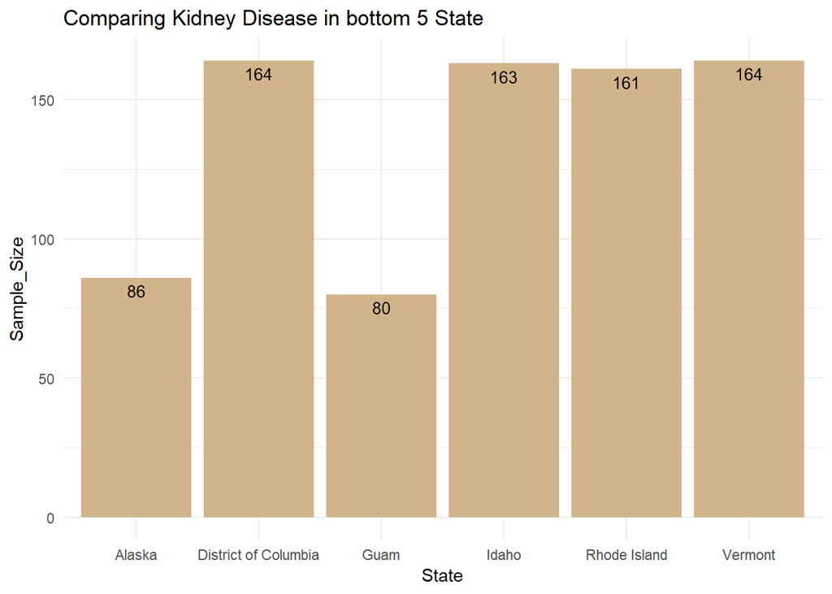

```r
# plotting the bottom 5 states with kidney disease for 2013
top_n(targ_kid3, n=-5, Sample_Size) %>%
  ggplot(., aes(x=Locationdesc, y=Sample_Size))+ labs(title = "Comparing Kidney Disease in bottom 5 State", x = "State") +
  geom_bar(stat = 'identity', fill = "tan")+ geom_text(aes(label=Sample_Size), vjust=1.5, color="black", size = 3.5)+ theme_minimal()
```

In 2013, FLorida had the highest number of Kidney diseases cases while Guam had the smallest number of cases.

**2014 kidney disease data**

```r
# getting kidney data 2014
targ_kid4 <- filter(targ_b, Year == "2014", Response == "Yes", Topic == "Kidney")
View(targ_kid4)
```

**getting the top 5 states with kidney disease 2014**

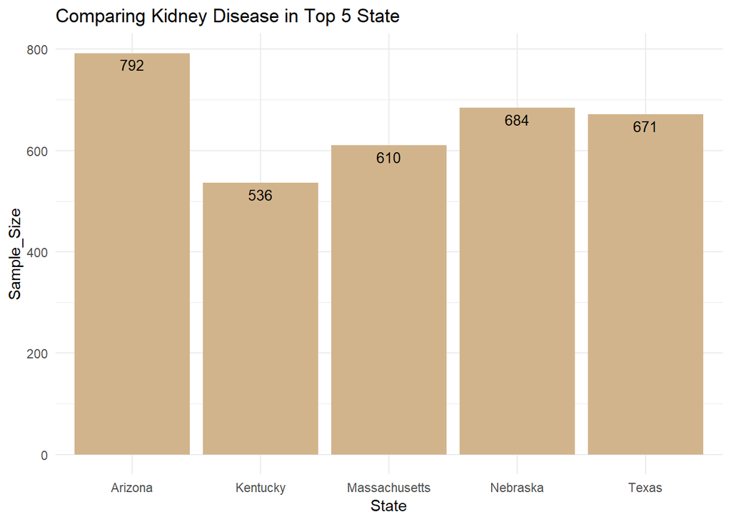

```r
# top 5 states with kidney disease 2014
top_n(targ_kid4, n=5, Sample_Size) %>%
  ggplot(., aes(x=Locationdesc, y=Sample_Size))+ labs(title = "Comparing Kidney Disease in Top 5 State", x = "State") +
  geom_bar(stat = 'identity', fill = "tan")+ geom_text(aes(label=Sample_Size), vjust=1.5, color="black", size = 3.5)+ theme_minimal()
```

getting bottom 5 states kidney disease 2014

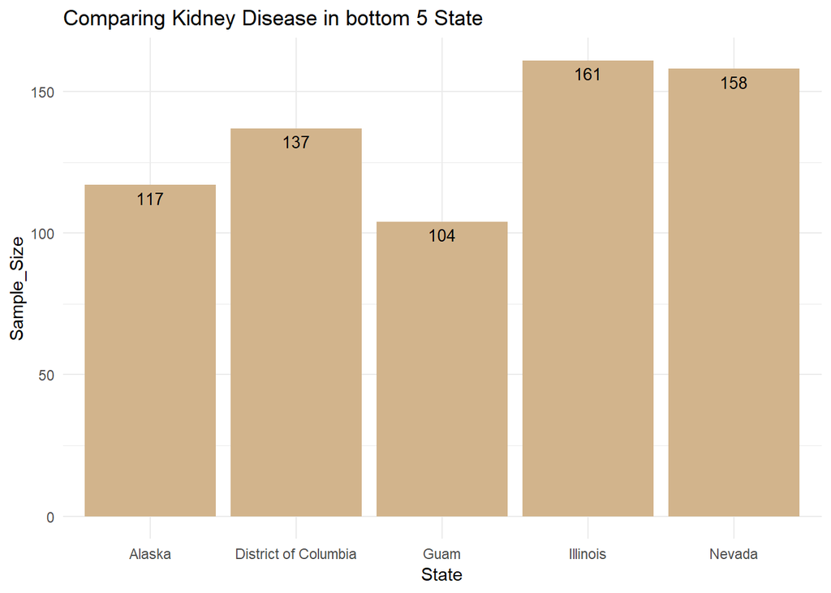

```r
# plotting the bottom 5 states with kidney disease for 2014
top_n(targ_kid4, n=-5, Sample_Size) %>%
  ggplot(., aes(x=Locationdesc, y=Sample_Size))+ labs(title = "Comparing Kidney Disease in bottom 5 State", x = "State") +
  geom_bar(stat = 'identity', fill = "tan")+ geom_text(aes(label=Sample_Size), vjust=1.5, color="black", size = 3.5)+ theme_minimal()
```

In 2014, Arizona topped the number of kidney diseases while Guam had th least number of cases recorded.

**2015 kidney disease data**

```r
# getting kidney data 2015
targ_kid5 <- filter(targ_b, Year == "2015", Response == "Yes", Topic == "Kidney")
View(targ_kid5)
```

**getting the top 5 states with kidney disease 2015**

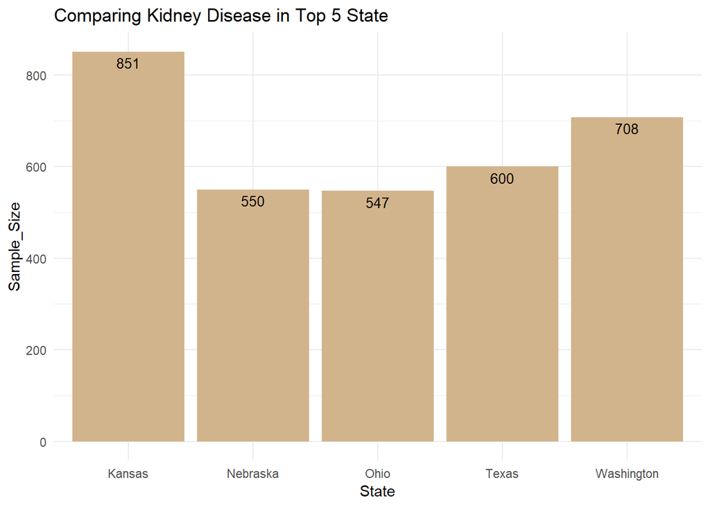

```r
# top 5 states with kidney disease 2015
top_n(targ_kid5, n=5, Sample_Size) %>%
  ggplot(., aes(x=Locationdesc, y=Sample_Size))+ labs(title = "Comparing Kidney Disease in Top 5 State", x = "State") +
  geom_bar(stat = 'identity', fill = "tan")+ geom_text(aes(label=Sample_Size), vjust=1.5, color="black", size = 3.5)+ theme_minimal()
```

**getting bottom 5 states kidney disease 2015**

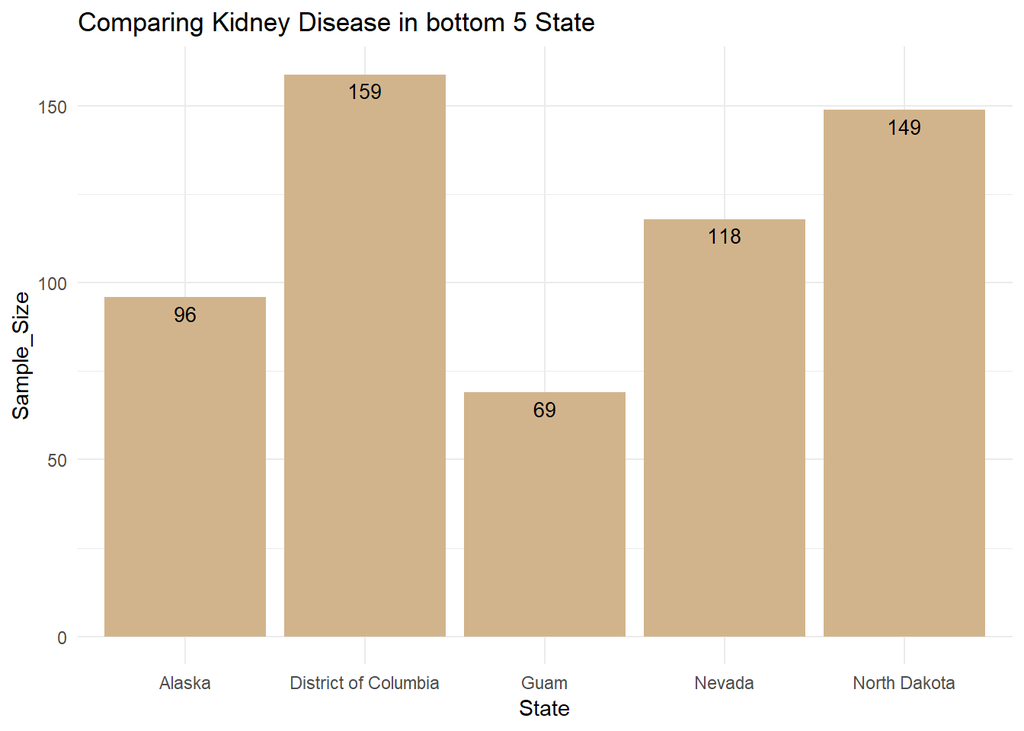

```r
# plotting the bottom 5 states with kidney disease for 2015
top_n(targ_kid5, n=-5, Sample_Size) %>%
  ggplot(., aes(x=Locationdesc, y=Sample_Size))+ labs(title = "Comparing Kidney Disease in bottom 5 State", x = "State") +
  geom_bar(stat = 'identity', fill = "tan")+ geom_text(aes(label=Sample_Size), vjust=1.5, color="black", size = 3.5)+ theme_minimal()
```

In 2015, Kansas had the highest number of kidney disease cases while Guam had the lowest number of cases.

**2016 kidney disease data**

```r
# getting kidney data 2016
targ_kid6 <- filter(targ_b, Year == "2016", Response == "Yes", Topic == "Kidney")
View(targ_kid6)
```

**getting the top 5 states with kidney disease 2016**

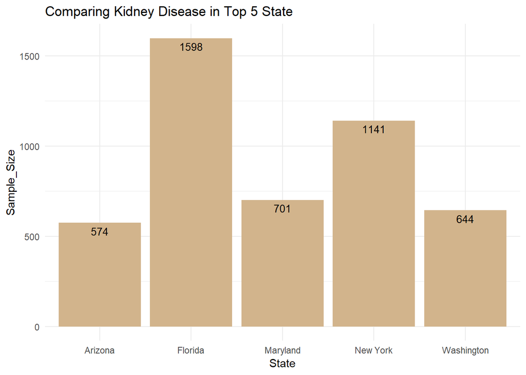

```r
# top 5 states with kidney disease 2016
top_n(targ_kid6, n=5, Sample_Size) %>%
  ggplot(., aes(x=Locationdesc, y=Sample_Size))+ labs(title = "Comparing Kidney Disease in Top 5 State", x = "State") +
  geom_bar(stat = 'identity', fill = "tan")+ geom_text(aes(label=Sample_Size), vjust=1.5, color="black", size = 3.5)+ theme_minimal()
```

**getting bottom 5 states kidney disease 2016**

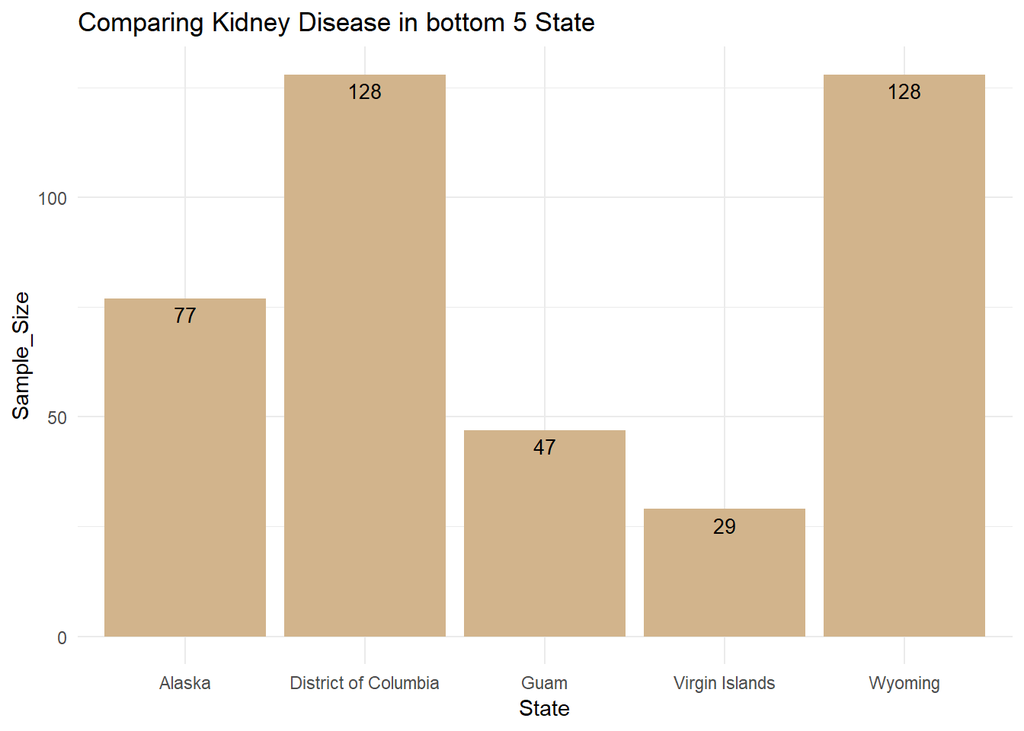

```r
# plotting the bottom 5 states with kidney disease for 2016
top_n(targ_kid6, n=-5, Sample_Size) %>%
  ggplot(., aes(x=Locationdesc, y=Sample_Size))+ labs(title = "Comparing Kidney Disease in bottom 5 State", x = "State") +
  geom_bar(stat = 'identity', fill = "tan")+ geom_text(aes(label=Sample_Size), vjust=1.5, color="black", size = 3.5)+ theme_minimal()
```

In 2016 FLorida had th highest cases of kidney disease whil Virgin Islands had the lowest cases.

**2017 kidney disease data**

```r
# getting kidney data 2017
targ_kid7 <- filter(targ_b, Year == "2017", Response == "Yes", Topic == "Kidney")
View(targ_kid7)
```

**getting the top 5 states with kidney disease 2017**

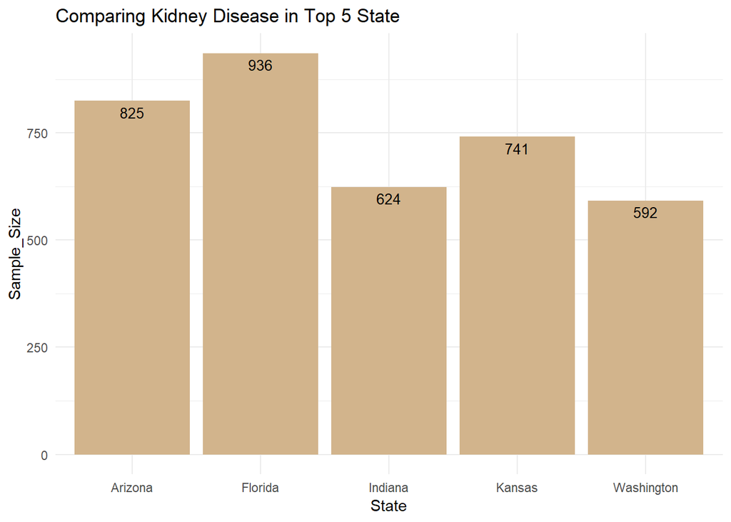

```r
# top 5 states with kidney disease 2017
top_n(targ_kid7, n=5, Sample_Size) %>%
  ggplot(., aes(x=Locationdesc, y=Sample_Size))+ labs(title = "Comparing Kidney Disease in Top 5 State", x = "State") +
  geom_bar(stat = 'identity', fill = "tan")+ geom_text(aes(label=Sample_Size), vjust=1.5, color="black", size = 3.5)+ theme_minimal()
```

**getting bottom 5 states kidney disease 2017**

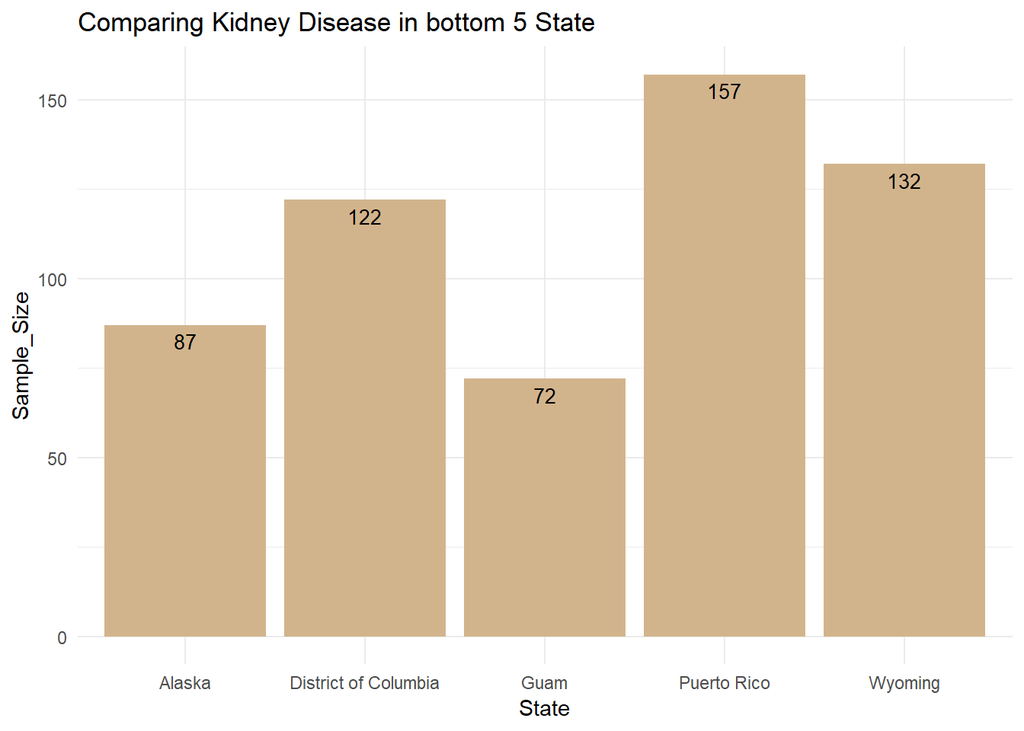

```r
# plotting the bottom 5 states with kidney disease for 2017
top_n(targ_kid7, n=-5, Sample_Size) %>%
  ggplot(., aes(x=Locationdesc, y=Sample_Size))+ labs(title = "Comparing Kidney Disease in bottom 5 State", x = "State") +
  geom_bar(stat = 'identity', fill = "tan")+ geom_text(aes(label=Sample_Size), vjust=1.5, color="black", size = 3.5)+ theme_minimal()
```

In 2017 Florida was still leading in kidney diseases cases while Guam was the lowest.

The next condition i looked at was binge drinking. This is a this is considered as men having at least 5 alcoholic drinks everyday. In this case am going to evaluate the top 5 and bottom 5 states where patients answered yes to binge drinking. First I obtained the relevant portion of the data set.

**2011 binge drinking disease data**

```r
# getting binge drinking data 2011
targ_binge <- filter(targ_b, Year == "2011", Response == "Yes", Topic == "Binge Drinking")
View(targ_binge)
```

**getting the top 5 states with binge drinking 2011**

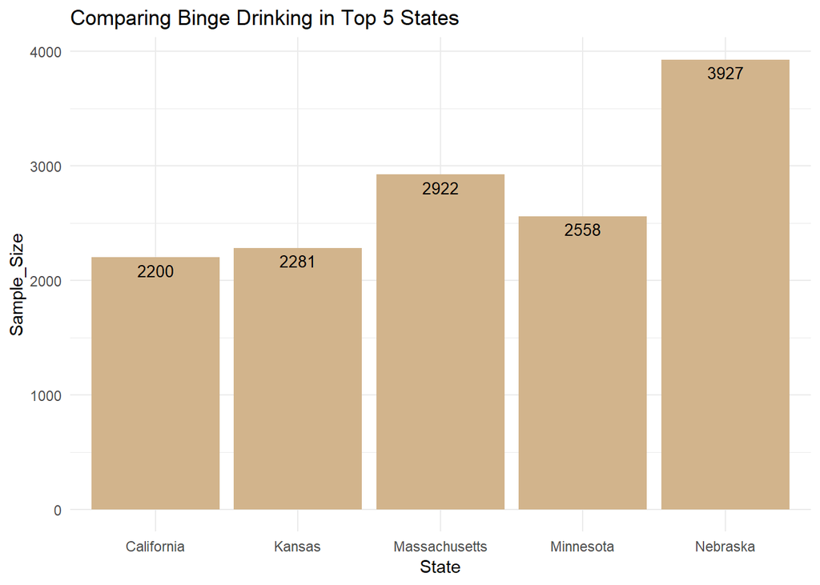

```r
# top 5 states with binge drinking 2011
top_n(targ_binge, n=5, Sample_Size) %>%
  ggplot(., aes(x=Locationdesc, y=Sample_Size))+ labs(title = "Comparing Binge Drinking in Top 5 States", x = "State") +
  geom_bar(stat = 'identity', fill = "tan")+ geom_text(aes(label=Sample_Size), vjust=1.5, color="black", size = 3.5)+ theme_minimal()
```

**getting bottom 5 states binge drinking 2011**

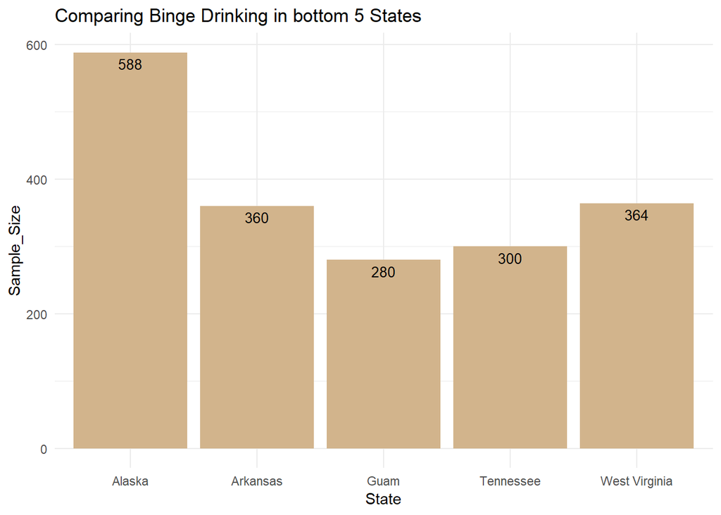

```r
# plotting the bottom 5 states with binge drinking for 2011
top_n(targ_binge, n=-5, Sample_Size) %>%
  ggplot(., aes(x=Locationdesc, y=Sample_Size))+ labs(title = "Comparing Binge Drinking in bottom 5 States", x = "State") +
  geom_bar(stat = 'identity', fill = "tan")+ geom_text(aes(label=Sample_Size), vjust=1.5, color="black", size = 3.5)+ theme_minimal()
```

In 2011, Nebraska had the highest number of recorded cases of Binge drinking while Guam had the least cases of binge drinking.